# Estimating Chi - examples

This notebook imports the temperature spectral data saved from matlab (from structure `diss.sclar_spectra.scalar_spec`), corrects for the frequency response of the sensor using Vachon and Lueck correction (used by Rockland in odas) and fits the model stated in Bluteau to the temperature spectrum to estimate $\chi$.

Data from profile_nr 32 was used for testing, dive depth was 414 m. 146 spectra were calculated.

```r
# read in data, mat structures are read as lists in R
spec <- readMat('../data/gradT_spectra_HPfilt_fftl2.mat')
diss <- readMat('../data/Diss_032_fft2.mat')
diss_fieldnames <- unlist(readMat('../data/diss_fieldnames_fft2.mat'))
print(diss_fieldnames)
```

```
  diss.fieldnames.fft21   diss.fieldnames.fft22   diss.fieldnames.fft23
                    "e"                 "K_max"               "warning"
  diss.fieldnames.fft24   diss.fieldnames.fft25   diss.fieldnames.fft26
               "method"                   "mad"                 "dof_e"
  diss.fieldnames.fft27   diss.fieldnames.fft28   diss.fieldnames.fft29
         "Nasmyth_spec"                    "sh"              "sh_clean"
 diss.fieldnames.fft210  diss.fieldnames.fft211  diss.fieldnames.fft212
                   "AA"                    "UA"                     "F"
 diss.fieldnames.fft213  diss.fieldnames.fft214  diss.fieldnames.fft215
                    "K"             "Data_fast"             "Data_slow"
 diss.fieldnames.fft216  diss.fieldnames.fft217  diss.fieldnames.fft218
                "speed"                    "nu"                     "P"
 diss.fieldnames.fft219  diss.fieldnames.fft220  diss.fieldnames.fft221
                    "T"                     "t"                   "AOA"
 diss.fieldnames.fft222  diss.fieldnames.fft223  diss.fieldnames.fft224
             "dof_spec"               "fs_fast"               "fs_slow"
 diss.fieldnames.fft225  diss.fieldnames.fft226  diss.fieldnames.fft227
                 "f_AA"               "f_limit"             "fit_order"
 diss.fieldnames.fft228  diss.fieldnames.fft229  diss.fieldnames.fft230
          "diss_length"               "overlap"            "fft_length"
 diss.fieldnames.fft231  diss.fieldnames.fft232  diss.fieldnames.fft233
                "piezo"             "fast_list"             "slow_list"
 diss.fieldnames.fft234  diss.fieldnames.fft235  diss.fieldnames.fft236
             "spikes_A"          "pass_count_A"            "fraction_A"
 diss.fieldnames.fft237  diss.fieldnames.fft238  diss.fieldnames.fft239
            "spikes_sh"         "pass_count_sh"           "fraction_sh"
 diss.fieldnames.fft240  diss.fieldnames.fft241  diss.fieldnames.fft242
             "spikes_C"          "pass_count_C"            "fraction_C"
 diss.fieldnames.fft243  diss.fieldnames.fft244  diss.fieldnames.fft245
"profiles_in_this_file"          "speed_source"                "params"
 diss.fieldnames.fft246  diss.fieldnames.fft247  diss.fieldnames.fft248
         "vehicle_info"        "scalar_spectra"    "scalar_vector_list"
 diss.fieldnames.fft249  diss.fieldnames.fft250  diss.fieldnames.fft251
          "scalar_info"               "ql_info"            "ql_info_in"
```

```r
# extract spectrum energy values from spec list
gradT1 <- spec[[1]][[1]][,1,]
gradT2 <- spec[[1]][[1]][,2,]
# wavenumber 2D matrix with each column for one depth segment from spec list
waven <- spec[[1]][[3]]
# frequency matrix from spec list
freq <- spec[[1]][[2]]
# additional variables
mean_speed <- diss[[1]][[16]]
pressure <- diss[[1]][[18]]
eps <- diss[[1]][[1]]
# delete unused variables
rm(diss, spec, diss_fieldnames)
print('structure of gradT1:')
```

```
[1] "structure of gradT1:"
```

```r
str(gradT1)
```

```
 num [1:1025, 1:146] 3.49e-05 1.17e-03 3.71e-03 2.92e-03 1.30e-03 ...
```

### Correcting for frequency response

```r
# correction as in odas library
# time constant for double-pole response:
F_0 <- 25*sqrt(mean_speed)
tau_therm <- 2*pi*F_0 / sqrt(sqrt(2) - 1)
tau_therm <- 1 / tau_therm
# correction:
# create a NA matrix for gradT1 and T2 of correct size and then fill with corrected values
gradT1_c <- matrix(data=NA, nrow=length(freq[,1]), ncol=length(freq[1,]))
gradT2_c <- matrix(data=NA, nrow=length(freq[,1]), ncol=length(freq[1,]))
for(index in 1:length(freq[1,])){
  gradT1_c[,index] <- gradT1[,index] * (1 + (2*pi*tau_therm[index]*freq[,index])^2)^2
  gradT2_c[,index] <- gradT2[,index] * (1 + (2*pi*tau_therm[index]*freq[,index])^2)^2
} # end for loop
```

#### Plot corrected sample spectra

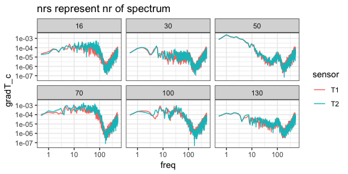

#### Fit model to spectra with $\chi$ as parameter estimated with MLE (maximum likelihood estimation)

model to fit:
$$\Psi_{\delta T/\delta x_i}(k) = C_T \chi \epsilon^{-1/3} k^{1/3}$$

with:

- $\Psi_{\delta T/\delta x_i}$ = corrected energy spectrum (`gradT_c`),
- $C_T$ = Obukhov-Corrsin universal constant with values between 0.3 and 0.5, 0.4 recommended,
- $\epsilon$ = dissipation energy estimated from shear probe signal (`eps`),
- $k$ = wavenumber ($k$ is here in rad/m, a conversion coefficient to convert to cpm should be added to the model?) (`waven`)

##### Convert measured spectra to wavenumber spectra by multiplying with mean_speed

```r
# make empty (NA) matrix of correct size
P_gradT1_c <- matrix(NA, nrow = length(gradT1_c[,1]), ncol=length(gradT1_c[1,]))
P_gradT2_c <- matrix(NA, nrow = length(gradT2_c[,1]), ncol=length(gradT2_c[1,]))
# fill matrix with converted values
for(index in 1:length(gradT1_c[,1])){
  P_gradT1_c[index,] <- gradT1_c[index,] * mean_speed
  P_gradT2_c[index,] <- gradT2_c[index,] * mean_speed
}
```

##### Find upper limit for $k$ for model fit using the criterium correction $H(k) \leq 3$ and $k \leq 0.1 \eta ^{-1}$

```r
# initialise K_max
K_max <- c()
# loop through all spectra in profile 32
for(segment in 1:146){
  # calculate correction factor Hf
  f <- freq[,segment]
  tau0 <- 4.1 * 10^-3
  speed0 <- 1
  tau <- tau0 * (mean_speed[segment,]/speed0)^(-0.5)
  Hf <- (1 + (2 * pi * tau *f)^2)^(2)
  # find range where Hf does not exceed 3
  ind <- length(Hf[Hf <= 3])
  # extract K for range where Hf <= 3
  K_max_seg = waven[ind,segment]

  # calculate eta (Kolmogorov length scale) from epsilon for check of second criterium for upper k
  eta <- (((10^-6)^3)/mean(eps[,segment]))^0.25 # Kolmogorov length scale

  # final upper limit of k
  K_max[segment] <- min(0.1/eta,K_max_seg)
}
```

##### Define x and y for model, only use spectrum for wavenumbers < K_max

```r
# initialise x and y as empty lists
x <- list()
y1 <- list()
y2 <- list()
# loop through all spectra for profile 32
for(segment in 1:146){
  K_min <- 0 # K_min needs to be checked after fitting, default value = 0
  # set lower k limit index
  min_ind <- max(length(waven[waven[,segment]<=K_min, segment]),2)
  # set upper k limit index
  max_ind <- length(waven[waven[,segment]<=K_max[segment],segment])
  # define y, y values are corrected wavenumber temp-gradient spectrum --> P_gradT1_c for chosen k range
  y1_seg <- P_gradT1_c[min_ind:max_ind,segment]
  y2_seg <- P_gradT2_c[min_ind:max_ind,segment]
  # define x, x values are k (wavenumbers) for chosen range
  x_seg <- waven[min_ind:max_ind,segment]
  # append x and y lists in each step
  y1 <- c(y1,list(y1_seg))
  y2 <- c(y2,list(y2_seg))
  x <- c(x,list(x_seg))
} # end for loop
# combine y1 and y2 in one list
y <- list(y1, y2)
```

##### maximum $k$ and number of spectral points included in estimating $\chi$ for sample spectra:

- spectrum 16: $k_{max}$ = 29.5, n = 74
- spectrum 30: $k_{max}$ = 19.3, n = 46
- spectrum 50: $k_{max}$ = 15.9, n = 37
- spectrum 70: $k_{max}$ = 21.9, n = 49
- spectrum 100: $k_{max}$ = 19.6, n = 41

##### definition of maximum likelihood function

```r
# define C_T
C_T <- 0.4
# initialise output fit and chi
fit <- list()
chi <- c()
# loop through both temp sensors
for(sensor in 1:2){
  fit_sens <- list()
  chi_sens <- c()
  # loop through each spectrum in profile 32
  for(segment in 1:146){
    xs <- x[[segment]]
    ys <- y[[sensor]][[segment]]
    #likelihood function definition
    LL <- function(chi) {
      # Find residuals
      R = ys - C_T * chi * mean(eps[,segment])^(-1/3) * xs^(1/3)
      # Calculate the likelihood for the residuals
      R = suppressWarnings(dnorm(R, log = TRUE))
      # Sum the log likelihoods for all of the data points
      -sum(R)
    } # end of LL function

    #model fit
    fit_seg <- suppressWarnings(mle(LL, start = list( chi=10^(-7))
                              ,nobs = length(ys),  method='L-BFGS-B'))
    fit_sens <- c(fit_sens, list(fit_seg))
    chi_sens <- c(chi_sens, fit_seg@coef[[1]])
  } # end for loop through spectra
  fit <- c(fit, list(fit_sens))
  chi <- list(chi, chi_sens)
} # end for loop through sensors
```

##### Estimated $\chi$ for sample spectra

```
[1] "spectrum 16: estimated Chi = 3.46e-07, Eps = 1.07e-08, logLik = -68, AIC = 138"
[1] "spectrum 30: estimated Chi = 4.1e-08, Eps = 1.38e-09, logLik = -42.3, AIC = 86.5"
[1] "spectrum 50: estimated Chi = 3.72e-07, Eps = 6.39e-10, logLik = -34, AIC = 70"
[1] "spectrum 70: estimated Chi = 6.31e-07, Eps = 2.29e-09, logLik = -45, AIC = 92.1"
[1] "spectrum 100: estimated Chi = 3.2e-07, Eps = 1.48e-09, logLik = -37.7, AIC = 77.4"
[1] "spectrum 130: estimated Chi = 5.01e-08, Eps = 6.58e-10, logLik = -29.4, AIC = 60.8"
```

##### calculate model with fitted $\chi$ for plotting

```r
spec_model <- list()
for(sensor in 1:2){
  spec_model_sens <- list()
  for(segment in 1:146){
    spec_model_seg <-  C_T * fit[[sensor]][[segment]]@coef[1] * mean(eps[,segment])^(-1/3) * x[[segment]]^(1/3)
    spec_model_sens <- c(spec_model_sens, list(spec_model_seg))
  }#end for loop through spectra
  spec_model <- c(spec_model, list(spec_model_sens))
}#end for loop through sensors
```

##### plot data and model for sample spectra

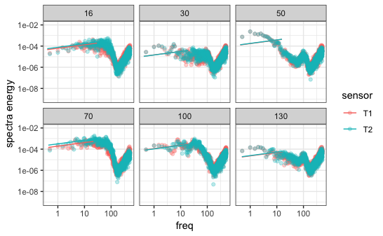

```r
pl_model <- data.frame()
for(segment in specnr_sub){
  k_model_s <- x[[segment]]
  spec_model1_s <- spec_model[[1]][[segment]]
  spec_model2_s <- spec_model[[2]][[segment]]
  pl_model <- pl_model %>%
      rbind(data.frame(k_model = k_model_s, T1 = spec_model1_s, T2 = spec_model2_s, specnr = as.factor(segment)) %>%
    gather(key = sensor, -k_model, -specnr, value = spec_model))
} #end for loop through spectra
pl_data <- gradT_df %>%
  filter(specnr %in% specnr_sub, freq != 0) %>%
  mutate(specnr = as.factor(specnr))
ggplot() +
  geom_point(data=pl_data, aes(x=freq, y = gradT_c, col = sensor), alpha = 0.3) +
  geom_line(data=pl_model, aes(x=k_model, y=spec_model, col = sensor)) +
  scale_y_continuous(trans='log10', limits=c(10^-9,10^-2)) +
  scale_x_continuous(trans='log10')  +
  labs(x = 'freq', y = 'spectra energy') +
  facet_wrap(~specnr, ncol = 3) +
  theme_bw()
```

##### check for lower $k$ condition using MAD (mean absolute deviation) between observed and modelled spectra

```r
# only checking T1 for now
MAD <- list()
crit <- list()
spec_good <- c()
  for(segment in 1:146){
    phi <- y[[1]][[segment]]   # corrected wavenumber temp-gradient = measured spectrum
    psi <- spec_model[[1]][[segment]]   # modelled spectrum
    steps <- 6  # 0.5-0.7 of a decade long?
    nr_steps <- floor(length(phi)/steps)
    modulo <- length(phi) %% steps
    if(modulo >= 4){
      nr_steps <- nr_steps + 1
    }
    # calculate MAD for steps of 6 values for the spectrum
    MAD_seg <- c()
    crit_seg <- c()
    for(i in 1:nr_steps){
      n_st <- (i-1) * steps + 1
      if(i == nr_steps){
        if(modulo >= 4){
          n_en <- n_st + modulo - 1
        }else{
          n_en <- n_st + steps - 1 + modulo
        }
      }else{
        n_en <- n_st + steps - 1
      }
      phi_n = phi[n_st:n_en]
      psi_n = psi[n_st:n_en]
      MAD_seg[i] <-  1/(length(phi_n)) * sum(abs(phi_n/psi_n - mean(phi_n/psi_n)))

      # check whether MAD fits criteria, crit = 0 (bad), 1 (good)
      dof <- length(phi_n) - 1   # degrees of freedom
      crit_seg[i] <- ifelse(MAD_seg[i] < 2 * (2/dof)^0.5, 1, 0)

    } # end for loop
    MAD <- c(MAD, list(MAD_seg))
    crit <- c(crit, list(crit_seg))
    spec_good <- c(spec_good, ifelse(sum(crit_seg)==length(crit_seg),1,0))
  }
  #If all subsets of the spectrum yielded a MAD>2(2/d)^1/2 (d = degrees of freedom   --> n-1 ?) (Ruddick et al. 2000), then the spectrum is completely discarded. Otherwise, the final wavenumber range used to obtain xF starts at the lowest wavenumber at which MAD<2(2/d)^1/2
```

There are 67 good spectra out of 146 spectra in the profile.

##### For our sample spectra:

```
[1] "spectrum 16: all MADs fulfill criteria, good spectrum"
[1] "spectrum 30: at least one MAD value outside allowed range, change minimum k"
[1] "spectrum 50: at least one MAD value outside allowed range, change minimum k"
[1] "spectrum 70: all MADs fulfill criteria, good spectrum"
[1] "spectrum 100: all MADs fulfill criteria, good spectrum"
[1] "spectrum 130: all MADs fulfill criteria, good spectrum"
```

##### Summary

So, from the MAD criteria check, about half of all spectra are good, but even some of the ‘good’ spectra don’t look right, e.g. spectrum 130 (see figure with model above).